# STAT5003: Decision Tree

Jiacheng Yang

## Aim and evaluation design

Predict the eight employment-status categories in Q279 using demographic and socioeconomic features. The shared baseline defines a stratified 60/20/20 Train/Validation/Test split, using seeds 5003 and 5005. Candidate configurations are selected by validation Macro F1, refitted on the complete 80% development pool, and evaluated on Test. Results below are generated during knitting.

Place the shared CSV beside this document, or set `STAT5003_DATA_PATH` to its location. The script checks the input checksum to preserve the agreed sample ordering. Required packages are `rpart`, `knitr`, and `rmarkdown`. Generated files are saved in `STAT5003_C_baseline_results`.

## Reproducible analysis code

The following code includes univariate EDA, class imbalance, an optional raw-data missingness audit, and decision-tree fitting. The search covers three feature specifications and 54 configurations of complexity parameter, maximum depth and minimum split size. All candidates use the full initial training partition. Numeric preprocessing is learned only from the fitting partition; categorical levels follow the shared codebook conventions.

```r
# STAT5003 C: decision tree aligned with the shared baseline (v2)
# Run using Source in RStudio or execute this file with Rscript.
# Uses the shared stratified 60/20/20 split and holdout validation for tuning.
# Fit on Train, select on Validation, refit on 80%, then evaluate once on Test.
# Only required package: rpart. No automatic installs or network requests.
# EDA and the optional original-data missingness audit are retained below.
# Shared CSV is never overwritten. Results are written to OUT_DIR.
#
# Source: https://github.com/ZhenmingSun2003-rgb/5003_Workspace
# baseline.Rmd blob: 7c83716a1f8186a40a17ab124da8bd9b8bfee430
# logistic Rmd blob: a676f73e891a56281129d9474c043f3a52a57bfa
# Split + metric functions below are copied verbatim from baseline.Rmd.
# Preprocessing follows the logistic file, including fit-only medians/scaling.
# Trees do not require scaling; it is retained for the shared recipe contract.
# Income_Group uses the SAME verified FY2021 mapping; NIR explicitly inherits UK High.
# A1 already imputed the whole CSV: inherited leakage remains a limitation.
# Do not claim raw missingness is zero or claim unseen-country generalisation.

# ========================== CONFIGURATION ================================
script_location <- function() {
  args <- commandArgs(trailingOnly = FALSE)
  arg <- sub("^--file=", "", args[grepl("^--file=", args)])
  if (length(arg)) return(dirname(normalizePath(arg[1], mustWork = TRUE)))
  for (frame in rev(sys.frames())) {
    if (!is.null(frame$ofile)) return(dirname(normalizePath(frame$ofile, mustWork = TRUE)))
  }
  getwd()
}
SCRIPT_DIR <- getwd()
# Optional override: Sys.setenv(STAT5003_DATA_PATH = "/path/to/shared.csv")
DATA_PATH <- Sys.getenv("STAT5003_DATA_PATH", "")
if (!nzchar(DATA_PATH)) {
  choices <- c(file.path(SCRIPT_DIR, "WVS_Wave7_cleaned_for_modelling.csv"),
    file.path(getwd(), "WVS_Wave7_cleaned_for_modelling.csv"),
    file.path(dirname(SCRIPT_DIR), "WVS_Wave7_cleaned_for_modelling.csv"))
  hits <- choices[file.exists(choices)]
  if (!length(hits)) stop("Put shared CSV beside script, or set STAT5003_DATA_PATH. For a Git clone, run git lfs pull.")
  DATA_PATH <- hits[1]
}
# Optional original, unimputed data. Leave empty to skip the raw missingness audit.
RAW_PATH <- Sys.getenv("STAT5003_RAW_PATH", "")
OUT_DIR <- Sys.getenv("STAT5003_OUT_DIR", file.path(SCRIPT_DIR, "STAT5003_C_baseline_results"))
RUN_MODEL <- TRUE
SEED <- 5003
TRAIN_FRACTION <- 0.80
TARGET_LEVELS <- as.character(1:8)
TARGET_LABELS <- c("Full-time", "Part-time", "Self-employed", "Retired",
                   "Housewife", "Student", "Unemployed", "Other")
REQUIRED_COLUMNS <- c("Q279", "B_COUNTRY_ALPHA", "Q260", "Q262", "Q270",
                      "Q273", "Q274", "Q275", "Q286", "Q287", "Q288")
EXPECTED_MD5 <- "98bf573170f0cb6bd65a4e9a8070d4d8"
EXPECTED_SHA256 <- "ee392676dbb42dde0ea74ebf643862f3900e7d13a7aa03842ed2d7665ac98ee0"
if (!file.exists(DATA_PATH) || file.info(DATA_PATH)$size < 1000) stop("Missing CSV or unmaterialised Git LFS pointer.")
DATA_PATH <- normalizePath(DATA_PATH)
input_md5 <- unname(tools::md5sum(DATA_PATH))
if (!identical(input_md5, EXPECTED_MD5)) stop("CSV differs from verified baseline input. Agree dataset/order with teammates before changing EXPECTED_MD5.")
status <- "BASELINE_ALIGNED_A1_IMPUTATION_CAVEAT"
# EDA variables; model feature specifications are defined separately below.
FEATURES <- c("Q260", "Q262", "Q270", "Q273", "Q274", "Q275", "Q286", "Q287", "Q288")
NUMERIC_FEATURES <- c("Q262", "Q270", "Q274")

dir.create(OUT_DIR, recursive = TRUE, showWarnings = FALSE)
write_table <- function(x, name) write.csv(x, file.path(OUT_DIR, name), row.names = FALSE)
save_plot <- function(name, draw, width = 1800, height = 1200) {
  png(file.path(OUT_DIR, name), width = width, height = height, res = 170)
  on.exit(dev.off(), add = TRUE)
  par(mar = c(8, 5, 4, 2) + 0.1)
  draw()
}
read_data <- function(path, cols = NULL) {
  # Read only requested columns to keep memory low; preserve code strings.
  header <- names(read.csv(path, nrows = 0, check.names = FALSE))
  if (!is.null(cols)) {
    absent <- setdiff(cols, header)
    if (length(absent)) stop("Missing columns: ", paste(absent, collapse = ", "))
  }
  classes <- if (is.null(cols)) "character" else ifelse(header %in% cols, "character", "NULL")
  read.csv(path, colClasses = classes, check.names = FALSE,
           na.strings = c("", "NA", "NaN"), stringsAsFactors = FALSE)
}
normalise_missing <- function(x) {
  x <- trimws(as.character(x))
  x[is.na(x) | x %in% c("", "NA", "NaN", "Unknown", "-1", "-2", "-3", "-4", "-5", "-999", "-9999")] <- NA_character_
  x
}
class_labels <- c("Full-time", "Part-time", "Self-employed", "Retired",
                  "Housewife", "Student", "Unemployed", "Other")
LABELS <- list(
  Q260 = c("Male", "Female"),
  Q273 = c("Married", "Living together", "Divorced", "Separated", "Widowed", "Single"),
  Q275 = c("No education", "Primary", "Lower secondary", "Upper secondary",
           "Post-secondary", "Short-cycle tertiary", "Bachelor", "Master", "Doctoral"),
  Q286 = c("Saved money", "Just got by", "Spent savings", "Spent savings and borrowed"),
  Q287 = c("Upper", "Upper middle", "Lower middle", "Working", "Lower"),
  Q288 = as.character(1:10))
VALID_CODES <- list(Q260 = 1:2, Q273 = 1:6, Q275 = 0:8, Q286 = 1:4, Q287 = 1:5, Q288 = 1:10)
pretty_names <- c(Q260 = "Gender", Q262 = "Age", Q270 = "Household size",
                  Q273 = "Marital status", Q274 = "Number of children",
                  Q275 = "Education", Q286 = "Family savings", Q287 = "Social class", Q288 = "Household income level")
# ============================ DATA / EDA =================================
if (!file.exists(DATA_PATH)) stop("Edit DATA_PATH: file not found.")
d <- read_data(DATA_PATH, unique(c("Q279", FEATURES)))
if (any(!d$Q279 %in% as.character(1:8))) {
  stop("DATA_PATH must have valid Q279 codes 1-8 for every row; ask A to filter targets before defining split row IDs.")
}
d$Q279 <- factor(d$Q279, levels = as.character(1:8), labels = class_labels)
d$row_id <- seq_len(nrow(d))
writeLines(c(paste("Result status:", status), paste("Source:", DATA_PATH),
             paste("Source MD5:", input_md5), paste("Verified shared CSV SHA256:", EXPECTED_SHA256),
             paste("Rows:", nrow(d)), paste("Features:", paste(FEATURES, collapse = ", ")),
             "No reweighting/resampling is applied.",
             "If source was already imputed, subsequent train-only preprocessing cannot undo the earlier leakage.",
             "No raw missingness claim may be made unless the optional audit below ran.",
             "The missingness audit covers the selected variables only, not all original features.",
             "Parameter choice uses CV macro F1. Undefined per-class precision/recall/F1 are assigned zero."),
           file.path(OUT_DIR, "READ_ME_FIRST.txt"))
freq <- as.data.frame(table(d$Q279), stringsAsFactors = FALSE)
names(freq) <- c("class", "n"); freq$percent <- 100 * freq$n / sum(freq$n)
write_table(freq, "target_distribution.csv")
write_table(data.frame(majority_minority_ratio = max(freq$n) / min(freq$n),
                       majority_baseline_accuracy = max(freq$n) / sum(freq$n)), "imbalance_summary.csv")
save_plot("01_target_distribution.png", function() {
  pos <- barplot(freq$n, names.arg = freq$class, las = 2, col = "steelblue",
                ylim = c(0, max(freq$n) * 1.2), ylab = "Respondents",
                main = "Q279: employment-status distribution")
  text(pos, freq$n, sprintf("%.1f%%", freq$percent), pos = 3, cex = 0.8)
})
num_summaries <- list()
for (v in FEATURES) {
  x <- normalise_missing(d[[v]])
  label <- if (v %in% names(pretty_names)) pretty_names[[v]] else v
  if (v %in% NUMERIC_FEATURES) {
    z <- suppressWarnings(as.numeric(x)); observed <- z[is.finite(z)]
    if (!length(observed)) next
    qs <- quantile(observed, c(.25, .5, .75)); spread <- qs[3] - qs[1]
    flagged <- observed < qs[1] - 1.5 * spread | observed > qs[3] + 1.5 * spread
    num_summaries[[v]] <- data.frame(variable = v, n_observed = length(observed),
      unavailable_in_supplied_data = sum(!is.finite(z)), mean = mean(observed),
      sd = sd(observed), min = min(observed), q1 = qs[1], median = qs[2], q3 = qs[3],
      max = max(observed), iqr_flagged = sum(flagged), row.names = NULL)
    save_plot(paste0("univariate_", v, ".png"), function() {
      hist(observed, breaks = 30, col = "steelblue", border = "white",
           main = paste(label, "- supplied-data distribution"), xlab = paste(label, paste0("(", v, ")")))
    })
  } else {
    if (v %in% names(VALID_CODES)) {
      codes <- as.character(VALID_CODES[[v]])
      x[!is.na(x) & !x %in% codes] <- "Invalid/unmapped"
      x <- factor(x, levels = c(codes, "Invalid/unmapped"),
                  labels = c(LABELS[[v]], "Invalid/unmapped"))
    }
    x <- as.character(x); x[is.na(x)] <- "Unavailable"
    levels_for_plot <- if (v %in% names(LABELS)) c(LABELS[[v]], "Invalid/unmapped", "Unavailable") else sort(unique(x))
    f <- as.data.frame(table(factor(x, levels = levels_for_plot)), stringsAsFactors = FALSE)
    names(f) <- c("category", "n"); f$percent <- 100 * f$n / nrow(d)
    write_table(f, paste0("univariate_", v, ".csv"))
    f <- f[f$n > 0, , drop = FALSE]
    save_plot(paste0("univariate_", v, ".png"), function() {
      barplot(f$n, names.arg = f$category, las = 2, col = "steelblue", ylab = "Respondents",
              main = paste(label, "- supplied-data distribution"), cex.names = .75)
    })
  }
}
if (length(num_summaries)) write_table(do.call(rbind, num_summaries), "numeric_summary.csv")
writeLines(c("EDA describes DATA_PATH, which may already be imputed.",
             "IQR flags are descriptive screening only. No observations were removed.",
             "Use the codebook and subject-matter reasoning to assess extreme values.",
             "Unavailable includes Unknown, NA and recognised special missing codes; it does NOT recover previously mode-imputed values."),
           file.path(OUT_DIR, "EDA_interpretation_notes.txt"))
```

```r
# =================== OPTIONAL PRE-IMPUTATION AUDIT ========================
if (nzchar(RAW_PATH)) {
  if (!file.exists(RAW_PATH)) stop("RAW_PATH file not found.")
  raw <- read_data(RAW_PATH, unique(c("Q279", FEATURES)))
  audit <- lapply(names(raw), function(v) {
    original <- raw[[v]]; clean <- normalise_missing(original)
    codes <- if (v == "Q279") 1:8 else VALID_CODES[[v]]
    invalid <- if (!is.null(codes)) !is.na(clean) & !clean %in% as.character(codes) else rep(FALSE, length(clean))
    # No undocumented age/household/children range is invented.
    data.frame(variable = v, n = length(original), original_na = sum(is.na(original)),
      recognised_missing_codes = sum(!is.na(original) & is.na(clean)),
      invalid_fixed_choice = sum(invalid),
      unavailable_before_imputation = sum(is.na(clean) | invalid),
      missing_percent = 100 * mean(is.na(clean) | invalid),
      over_50_percent = mean(is.na(clean) | invalid) > .5)
  })
  audit <- do.call(rbind, audit)
  write_table(audit, "raw_selected_variables_missingness.csv")
  save_plot("02_raw_missingness.png", function() {
    a <- audit[order(audit$missing_percent, decreasing = TRUE), ]
    barplot(a$missing_percent, names.arg = a$variable, col = "tomato3", las = 2,
            ylim = c(0, 100), ylab = "Unavailable before imputation (%)",
            main = "Original sample: selected-variable missingness (scoped audit)")
    abline(h = 50, lty = 2)
  })
  # Pattern frequencies: 1 = unavailable; 0 = observed, selected variables only.
  mask <- sapply(names(raw), function(v) {
    z <- normalise_missing(raw[[v]])
    codes <- if (v == "Q279") 1:8 else VALID_CODES[[v]]
    is.na(z) | if (!is.null(codes)) !z %in% as.character(codes) else FALSE
  })
  patterns <- sort(table(apply(mask, 1, function(x) paste(as.integer(x), collapse = ""))), decreasing = TRUE)
  write_table(data.frame(pattern = names(patterns), n = as.integer(patterns)), "raw_missing_patterns.csv")
  writeLines(paste("Pattern column order:", paste(names(raw), collapse = ", ")),
             file.path(OUT_DIR, "raw_missing_pattern_key.txt"))
  save_plot("03_raw_missing_patterns.png", function() {
    top <- head(patterns, 12)
    barplot(top, las = 2, col = "tomato3", ylab = "Respondents",
            main = "Top missingness patterns: 1 = unavailable, 0 = observed", cex.names = .8)
  })
} else {
  writeLines("SKIPPED: no original CSV supplied. Do not report zero original missingness. Set RAW_PATH and rerun.",
             file.path(OUT_DIR, "raw_missingness_NOT_AVAILABLE.txt"))
}


# ===================== BASELINE-ALIGNED DECISION TREE =====================
if (RUN_MODEL) {
if (!requireNamespace("rpart", quietly = TRUE)) stop("Install package rpart to run modelling.")
read_selected_columns <- function(path, names_wanted) {
  names_all <- names(read.csv(path, nrows = 0, check.names = FALSE))
  missing <- setdiff(names_wanted, names_all)
  if (length(missing)) stop("Missing CSV columns: ", paste(missing, collapse = ", "))
  types <- rep("NULL", length(names_all))
  types[match(names_wanted, names_all)] <- NA_character_
  read.csv(path, colClasses = types, check.names = FALSE,
           na.strings = c("", "NA"), stringsAsFactors = FALSE)
}


wvs <- read_selected_columns(DATA_PATH, REQUIRED_COLUMNS)
stopifnot(nrow(wvs) == 95987L, all(as.character(wvs$Q279) %in% TARGET_LEVELS))
wvs$Outcome <- factor(as.character(wvs$Q279), levels = TARGET_LEVELS, labels = TARGET_LABELS)
WB_GROUPS <- list(
  Low = c("ETH", "TJK"),
  `Lower-middle` = c("BGD", "BOL", "EGY", "IND", "KEN", "KGZ", "MAR", "MMR", "MNG",
                     "NGA", "NIC", "PAK", "PHL", "TUN", "UKR", "UZB", "VNM", "ZWE"),
  `Upper-middle` = c("ARG", "ARM", "BRA", "CHN", "COL", "ECU", "GTM", "IDN", "IRN",
                     "IRQ", "JOR", "KAZ", "LBN", "LBY", "MDV", "MEX", "MYS", "PER",
                     "RUS", "SRB", "THA", "TUR", "VEN"),
  High = c("AND", "AUS", "CAN", "CHL", "CYP", "CZE", "DEU", "GBR", "GRC", "HKG", "JPN",
           "KOR", "MAC", "NIR", "NLD", "NZL", "PRI", "ROU", "SGP", "SVK", "TWN", "URY",
           "USA"),
  Unclassified = character(0)
)
country_group <- setNames(rep(names(WB_GROUPS), lengths(WB_GROUPS)),
                          unlist(WB_GROUPS, use.names = FALSE))
stopifnot(!anyDuplicated(names(country_group)))
not_mapped <- setdiff(unique(as.character(wvs$B_COUNTRY_ALPHA)), names(country_group))
if (length(not_mapped)) stop("Country mapping requires review: ", paste(not_mapped, collapse = ", "))
wvs$Income_Group <- unname(country_group[as.character(wvs$B_COUNTRY_ALPHA)])

# VERBATIM baseline common-split, excluding its knitr table call:
stratified_indices <- function(y, fraction, seed) {
  set.seed(seed)
  groups <- split(seq_along(y), y, drop = TRUE)
  sort(unlist(lapply(groups, function(ii) sample(ii, floor(length(ii) * fraction))),
              use.names = FALSE))
}
train_id <- stratified_indices(wvs$Outcome, TRAIN_FRACTION, SEED)
test_id <- setdiff(seq_len(nrow(wvs)), train_id)
train <- wvs[train_id, , drop = FALSE]
test <- wvs[test_id, , drop = FALSE]
stopifnot(!length(intersect(train_id, test_id)),
          length(train_id) + length(test_id) == nrow(wvs),
          all(table(train$Outcome) > 0), all(table(test$Outcome) > 0))
# Shared within-development split. Indices in dev_id and val_id refer to
# the 80% training pool; train_id and test_id refer to the original CSV.
dev_id <- stratified_indices(train$Outcome, 0.75, SEED + 2)
val_id <- setdiff(seq_len(nrow(train)), dev_id)
stopifnot(!length(intersect(dev_id, val_id)),
          length(dev_id) + length(val_id) == nrow(train))
initial_train <- train[dev_id, , drop = FALSE]
validation <- train[val_id, , drop = FALSE]
share_table <- data.frame(Class = TARGET_LABELS,
                          Train = as.integer(table(initial_train$Outcome)),
                          Validation = as.integer(table(validation$Outcome)),
                          Test = as.integer(table(test$Outcome)))
cat("Seed:", SEED, "| Train:", nrow(initial_train),
    "| Validation:", nrow(validation), "| Test:", nrow(test),
    "| Final refit Train+Validation:", nrow(train), "\n")
stopifnot(nrow(initial_train) == 57587L, nrow(validation) == 19199L,
          nrow(test) == 19201L, nrow(train) == 76786L)
write_table(share_table, "shared_class_counts.csv")
partition <- rep("Test", nrow(wvs))
partition[train_id[dev_id]] <- "Train"
partition[train_id[val_id]] <- "Validation"
write_table(data.frame(row_id = seq_len(nrow(wvs)), split = partition,
                        Q279 = wvs$Q279), "shared_split_row_ids.csv")
# train_id/test_id refer to original rows; dev_id/val_id to the 80% pool.
saveRDS(list(train_id = train_id, test_id = test_id, dev_id = dev_id, val_id = val_id,
             input_md5 = input_md5), file.path(OUT_DIR, "shared_split_indices.rds"))
```

```r
# VERBATIM baseline eight-class evaluator:
evaluate_8class <- function(truth, pred, show_confusion = TRUE) {
  tr <- factor(as.character(truth), levels = TARGET_LABELS)
  pr <- factor(as.character(pred), levels = TARGET_LABELS)
  if (anyNA(tr) || anyNA(pr)) stop("Unknown/missing prediction class")
  cm <- table(True = tr, Predicted = pr)
  tp <- diag(cm)
  support <- rowSums(cm)
  predicted <- colSums(cm)
  precision <- ifelse(predicted > 0, tp / predicted, 0)
  recall <- ifelse(support > 0, tp / support, 0)
  f1 <- ifelse(precision + recall > 0,
               2 * precision * recall / (precision + recall), 0)
  by_class <- data.frame(Class = TARGET_LABELS, Support = as.integer(support),
                         Precision = round(precision, 4), Recall = round(recall, 4),
                         F1 = round(f1, 4), row.names = NULL)
  overall <- data.frame(Macro_F1 = mean(f1),
                        Weighted_F1 = sum(support * f1) / sum(support),
                        Accuracy = sum(tp) / sum(cm))
  if (show_confusion) print(cm)
  list(overall = overall, by_class = by_class, confusion = cm)
}

# Same train-fitted recipe as logistic Rmd; no Age_sq in tree specifications.
NUMERIC_KEYS <- c(Age="Q262",HouseholdSize="Q270",Children="Q274")
CATEGORY_KEYS <- list(
  Gender=as.character(1:2),Marital=as.character(1:6),
  Education=as.character(0:8),SocialClass=as.character(1:5),
  IncomeBracket=as.character(1:10),Savings=as.character(1:4),
  Income_Group=c("Low","Lower-middle","Upper-middle","High","Unclassified"))
CATEGORY_SOURCES <- c(Gender="Q260",Marital="Q273",Education="Q275",
                      SocialClass="Q287",IncomeBracket="Q288",
                      Savings="Q286",Income_Group="Income_Group")
numeric_value <- function(v) {
  x <- suppressWarnings(as.numeric(as.character(v)))
  x[!is.finite(x)] <- NA_real_
  x
}
learn_recipe <- function(raw) {
  num <- lapply(NUMERIC_KEYS,function(k) numeric_value(raw[[k]]))
  med <- vapply(num,function(x) if(all(is.na(x))) 0 else median(x,na.rm=TRUE),0.0)
  filled <- Map(function(x,m) {x[is.na(x)] <- m;x},num,med)
  mu <- vapply(filled,mean,0.0)
  sigma <- vapply(filled,sd,0.0)
  sigma[is.na(sigma)|sigma==0] <- 1
  list(median=med,mean=mu,sd=sigma)
}
apply_recipe <- function(raw,r) {
  out <- data.frame(Outcome=factor(as.character(raw$Outcome),levels=TARGET_LABELS))
  for (nm in names(NUMERIC_KEYS)) {
    x <- numeric_value(raw[[NUMERIC_KEYS[[nm]]]])
    missing <- is.na(x)
    x[missing] <- r$median[[nm]]
    out[[nm]] <- (x-r$mean[[nm]])/r$sd[[nm]]
    out[[paste0(nm,"_missing")]] <- as.integer(missing)
  }
  out$Age_sq <- out$Age^2
  for(nm in names(CATEGORY_KEYS)) {
    v <- trimws(as.character(raw[[CATEGORY_SOURCES[[nm]]]]))
    v[is.na(v)|!(v %in% CATEGORY_KEYS[[nm]])] <- "Missing"
    out[[nm]] <- factor(v,levels=c(CATEGORY_KEYS[[nm]],"Missing"))
  }
  out
}

# Predetermined search; no candidate is selected by looking at Test scores.
# Core and extended match the logistic feature sets. The third set isolates
# the contribution of the fixed FY2021 country-income proxy within extended.
# Quadratic age is omitted: a tree already makes nonlinear age partitions.
SPECIFICATIONS <- list(
  core_linear = c("Age", "Age_missing", "Gender", "Marital", "Education", "SocialClass", "IncomeBracket"),
  extended_no_income_group = c("Age", "Age_missing", "HouseholdSize", "HouseholdSize_missing",
    "Children", "Children_missing", "Gender", "Marital", "Education", "SocialClass", "IncomeBracket", "Savings"),
  extended_linear = c("Age", "Age_missing", "HouseholdSize", "HouseholdSize_missing",
    "Children", "Children_missing", "Gender", "Marital", "Education", "SocialClass", "IncomeBracket", "Savings", "Income_Group"))
GRID <- expand.grid(Spec = names(SPECIFICATIONS), cp = c(0.0005, 0.001, 0.005),
                    maxdepth = c(4L, 8L, 12L), minsplit = c(20L, 100L),
                    stringsAsFactors = FALSE)
write_table(GRID, "prespecified_search_grid.csv")
fit_tree <- function(raw_prepared, spec, cp, maxdepth, minsplit) {
  rpart::rpart(reformulate(SPECIFICATIONS[[spec]], response = "Outcome"),
    data = raw_prepared, method = "class", parms = list(split = "gini"),
    control = rpart::rpart.control(cp = cp, maxdepth = maxdepth, minsplit = minsplit, xval = 0))
}
initial_recipe <- learn_recipe(initial_train)
X_initial <- apply_recipe(initial_train, initial_recipe)
X_validation <- apply_recipe(validation, initial_recipe)
ranking <- vector("list", nrow(GRID))
for (i in seq_len(nrow(GRID))) {
  candidate <- GRID[i, ]
  fit <- fit_tree(X_initial, candidate$Spec, candidate$cp, candidate$maxdepth, candidate$minsplit)
  val_pred <- predict(fit, newdata = X_validation, type = "class")
  ev <- evaluate_8class(X_validation$Outcome, val_pred, FALSE)
  leaves <- sum(fit$frame$var == "<leaf>")
  ranking[[i]] <- cbind(candidate, Leaves = leaves, Train_N = nrow(X_initial),
                        Validation_N = nrow(X_validation), ev$overall)
  if (i %% 9 == 0 || i == nrow(GRID)) cat("Validation search:", i, "/", nrow(GRID), "\n")
}
ranking <- do.call(rbind, ranking)
# Ties: weighted F1, fewer leaves, simpler feature set, shallower tree,
# then stronger pruning and larger minimum split size.
ranking <- ranking[order(-ranking$Macro_F1, -ranking$Weighted_F1, ranking$Leaves,
  match(ranking$Spec, names(SPECIFICATIONS)), ranking$maxdepth, -ranking$cp, -ranking$minsplit), ]
rownames(ranking) <- NULL
write_table(ranking, "validation_tuning_results.csv")
best <- ranking[1, , drop = FALSE]
write_table(best, "selected_validation_configuration.csv")
best_each <- ranking[!duplicated(ranking$Spec), , drop = FALSE]
write_table(best_each, "validation_feature_sensitivity.csv")
save_plot("validation_comparison.png", function() {
  labs <- c(core_linear = "Core", extended_no_income_group = "Extended, no proxy",
             extended_linear = "Extended + proxy")
  pos <- barplot(best_each$Macro_F1, names.arg = unname(labs[best_each$Spec]),
    ylim = c(0, max(best_each$Macro_F1) * 1.2), col = "steelblue", las = 2,
    ylab = "Validation Macro F1", main = "Best validation result per feature specification")
  text(pos, best_each$Macro_F1, sprintf("%.3f", best_each$Macro_F1), pos = 3)
})
cat("Selected using Validation only:\n"); print(best)
```

```r
# Relearn recipe and refit the selected configuration on ALL 80% records.
final_recipe <- learn_recipe(train)
X_train <- apply_recipe(train, final_recipe)
X_test <- apply_recipe(test, final_recipe)
final_tree <- fit_tree(X_train, best$Spec, best$cp, best$maxdepth, best$minsplit)
# The only Test prediction call for the fitted decision tree:
test_prediction <- predict(final_tree, newdata = X_test, type = "class")
test_eval <- evaluate_8class(X_test$Outcome, test_prediction, TRUE)
majority <- names(which.max(table(train$Outcome)))
majority_eval <- evaluate_8class(test$Outcome, rep(majority, nrow(test)), FALSE)
comparison <- rbind(data.frame(Model = "Training-majority", majority_eval$overall),
                    data.frame(Model = paste("DecisionTree", best$Spec), test_eval$overall))
write_table(comparison, "test_model_comparison.csv")
write_table(test_eval$overall, "decision_tree_test_metrics.csv")
write_table(test_eval$by_class, "decision_tree_per_class_metrics.csv")
write_table(as.data.frame(test_eval$confusion), "decision_tree_confusion_matrix.csv")
write_table(data.frame(row_id = test_id, truth = test$Outcome, prediction = test_prediction),
              "decision_tree_test_predictions.csv")
writeLines(capture.output(print(final_tree)), file.path(OUT_DIR, "decision_tree_rules.txt"))
importance <- final_tree$variable.importance
if (length(importance)) write_table(data.frame(Feature = names(importance), Importance = unname(importance)),
                                    "decision_tree_variable_importance.csv")
saveRDS(list(model = final_tree, recipe = final_recipe,
  specification = best$Spec, features = SPECIFICATIONS[[best$Spec]], best = best,
  country_map = country_group, input_md5 = input_md5,
  baseline_blob = "7c83716a1f8186a40a17ab124da8bd9b8bfee430",
  split = list(train_id = train_id, test_id = test_id, dev_id = dev_id, val_id = val_id),
  status = status), file.path(OUT_DIR, "decision_tree_model_bundle.rds"))

save_plot("decision_tree_confusion_heatmap.png", function() {
  m <- test_eval$confusion / rowSums(test_eval$confusion)
  par(mar = c(8, 8, 4, 2))
  image(1:8, 1:8, t(m[8:1, ]), axes = FALSE,
    col = colorRampPalette(c("white", "steelblue4"))(100), zlim = c(0, 1),
    xlab = "", ylab = "", main = "Decision tree: Test confusion matrix (row-normalised)")
  axis(1, at = 1:8, labels = TARGET_LABELS, las = 2, cex.axis = .75)
  axis(2, at = 1:8, labels = rev(TARGET_LABELS), las = 2, cex.axis = .75)
  for (i in 1:8) for (j in 1:8) text(j, 9-i, sprintf("%.0f%%", 100*m[i,j]),
    col = if (m[i,j] > .5) "white" else "black", cex = .8)
  mtext("Predicted class", 1, line = 6); mtext("True class", 2, line = 6)
})
if (nrow(final_tree$frame) > 1) {
  # Full text rules are always saved. For large trees, avoid an unreadable plot.
  if (sum(final_tree$frame$var == "<leaf>") <= 32L) {
    save_plot("decision_tree.png", function() {
      par(mar = c(1, 1, 4, 1)); plot(final_tree, uniform = TRUE, margin = .1)
      text(final_tree, use.n = FALSE, all = TRUE, cex = .7, pretty = 0)
      title("Selected decision tree: refit on Train + Validation",
        sub = "Numeric split thresholds use the training-fitted standardised scale")
    }, width = 3200, height = 2200)
  } else {
    # This is a labelled illustrative pruning, NOT the evaluated full model.
    display_cp <- max(final_tree$cptable[final_tree$cptable[, "nsplit"] <= 14, "CP"])
    eligible <- final_tree$cptable[final_tree$cptable[, "nsplit"] <= 14, , drop = FALSE]
    if (nrow(eligible)) display_cp <- min(eligible[, "CP"])
    display_tree <- rpart::prune(final_tree, cp = display_cp)
    if (nrow(display_tree$frame) > 1) save_plot("decision_tree_illustrative_pruning.png", function() {
      par(mar = c(1, 1, 5, 1)); plot(display_tree, uniform = TRUE, margin = .1)
      text(display_tree, use.n = FALSE, all = TRUE, cex = .7, pretty = 0)
      title("Illustrative pruning only - not the evaluated full tree")
    }, width = 3200, height = 2200)
  }
}
summary_lines <- c(
  "STAT5003 C: completed baseline-aligned decision-tree run",
  paste("Input:", DATA_PATH), paste("Input MD5:", input_md5),
  paste("Verified input SHA256:", EXPECTED_SHA256),
  "baseline.Rmd blob: 7c83716a1f8186a40a17ab124da8bd9b8bfee430",
  "Split seeds: 5003 for 80/20; 5005 for within-development 75/25.",
  sprintf("Train: %d; Validation: %d; Test: %d; final refit: %d",
    nrow(initial_train), nrow(validation), nrow(test), nrow(train)),
  paste("Selected specification:", best$Spec),
  sprintf("Parameters: cp=%g, maxdepth=%d, minsplit=%d", best$cp, best$maxdepth, best$minsplit),
  sprintf("Selection Validation Macro F1: %.6f", best$Macro_F1),
  sprintf("Test Macro F1: %.6f; Weighted F1: %.6f; Accuracy: %.6f",
    test_eval$overall$Macro_F1, test_eval$overall$Weighted_F1, test_eval$overall$Accuracy),
  paste("Final leaves:", sum(final_tree$frame$var == "<leaf>")),
  "All candidates used the full 60% Train. No development subsampling and no CV.",
  "Single holdout Validation selects configuration; Test is not used for selection.",
  "Inherited limitation: A1 mode imputation used the whole CSV before this split.",
  "Income_Group follows the verified frozen FY2021 map; NIR explicitly inherits UK High.",
  "Raw missingness audit is optional and skipped unless STAT5003_RAW_PATH is set.",
  "Descriptive IQR flags are not invalid-value decisions; no observations were removed.",
  "The illustrative pruned plot, if present, is not the evaluated full model.",
  "Core/extended specification labels match the logistic file; a decision tree remains nonlinear.")
writeLines(summary_lines, file.path(OUT_DIR, "RUN_SUMMARY.txt"))
print(comparison)
}
writeLines(capture.output(sessionInfo()), file.path(OUT_DIR, "sessionInfo.txt"))
cat("Done. Results:", normalizePath(OUT_DIR), "\n")
```

## Shared sample split

Table 1. Class counts in the shared Train, Validation and Test partitions.

| Class | Train | Validation | Test |
| --- | --- | --- | --- |
| Full-time | 20981 | 6994 | 6994 |
| Part-time | 4959 | 1653 | 1654 |
| Self-employed | 8250 | 2751 | 2751 |
| Retired | 7247 | 2416 | 2416 |
| Housewife | 7642 | 2548 | 2548 |
| Student | 3382 | 1128 | 1128 |
| Unemployed | 4431 | 1477 | 1478 |
| Other | 695 | 232 | 232 |

## Class imbalance

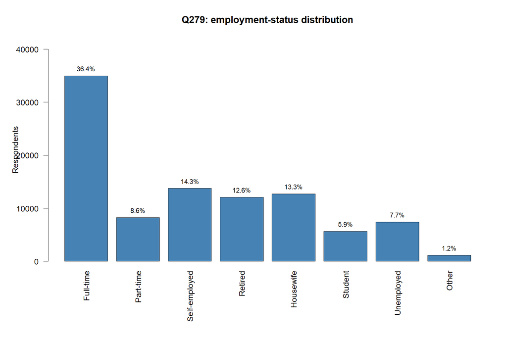

Figure 1. Employment-status frequencies in the shared cleaned dataset.

## Validation-based model selection

Table 2. Configuration selected using validation scores only.

| Spec | cp | maxdepth | minsplit | Leaves | Train_N | Validation_N | Macro_F1 | Weighted_F1 | Accuracy |
| --- | --- | --- | --- | --- | --- | --- | --- | --- | --- |
| extended_linear | 5e-04 | 8 | 100 | 21 | 57587 | 19199 | 0.3391 | 0.4646 | 0.5275 |

Table 3. Best validation result for each feature specification.

|  | Spec | cp | maxdepth | minsplit | Leaves | Train_N | Validation_N | Macro_F1 | Weighted_F1 | Accuracy |
| --- | --- | --- | --- | --- | --- | --- | --- | --- | --- | --- |
| 1 | extended_linear | 5e-04 | 8 | 100 | 21 | 57587 | 19199 | 0.3391 | 0.4646 | 0.5275 |
| 9 | core_linear | 5e-04 | 8 | 100 | 12 | 57587 | 19199 | 0.3020 | 0.4189 | 0.5113 |
| 11 | extended_no_income_group | 5e-04 | 12 | 100 | 19 | 57587 | 19199 | 0.3019 | 0.4200 | 0.5150 |

## Final held-out evaluation

Table 4. Test performance after refitting the selected configuration on 80% of the data.

| Model | Macro_F1 | Weighted_F1 | Accuracy |
| --- | --- | --- | --- |
| Training-majority | 0.0667 | 0.1945 | 0.3643 |
| DecisionTree extended_linear | 0.3353 | 0.4620 | 0.5271 |

Table 5. Test precision, recall and F1 for all eight classes.

| Class | Support | Precision | Recall | F1 |
| --- | --- | --- | --- | --- |
| Full-time | 6994 | 0.5517 | 0.7811 | 0.6467 |
| Part-time | 1654 | 0.0000 | 0.0000 | 0.0000 |
| Self-employed | 2751 | 0.3506 | 0.2116 | 0.2639 |
| Retired | 2416 | 0.6392 | 0.7641 | 0.6961 |
| Housewife | 2548 | 0.4690 | 0.5640 | 0.5121 |
| Student | 1128 | 0.4701 | 0.7030 | 0.5634 |
| Unemployed | 1478 | 0.0000 | 0.0000 | 0.0000 |
| Other | 232 | 0.0000 | 0.0000 | 0.0000 |

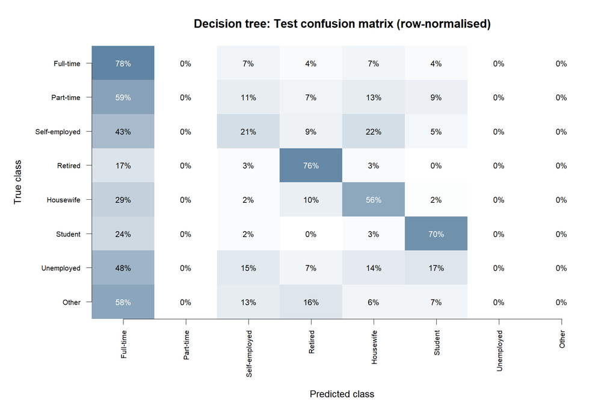

Figure 2. Test confusion matrix normalised within true classes.

## Interpretation and limitations

> **Legacy pre-correction interpretation:** the fixed zero-prediction claim below belongs to the original map; consult newly generated class counts and recall for the corrected run.

Inspect the per-class results alongside Macro F1: the tested configuration does not predict Part-time, Unemployed or Other, giving zero recall for these classes. The fitted leaf decisions favour the remaining classes. Class imbalance and insufficient separation under the selected features and tree constraints are plausible contributing factors; the results do not establish a single cause.

The shared A1 CSV was already imputed before splitting, so this analysis avoids additional fitted-preprocessing leakage but cannot remove the inherited risk. The country-income mapping is verified against the frozen FY2021 historical table; it is not survey-year-specific and NIR inherits UK High. Original missingness cannot be reconstructed from the imputed CSV; the optional audit is skipped unless original data are supplied. Random individual-level holdout does not establish performance in unseen countries or future years. This document is a model contribution to the group report, not the complete final submission.